# Introduction to DAGassist

Graham Goff and Mike Denly

2026-08-19

## Introduction

*DAGassist* contains tools for using directed acyclic graphs (DAGs) to align regressions with an estimand and its identifying assumptions. DAGs are causal graphs that nonparametrically encode the relationships between a model’s variables. For good introductory articles on DAGs, see Pearl (1995), Pearl (2009), Hünermund et al. (2025), and Elwert (2013).

The *DAGassist* workflow has five steps: (1) declare an estimand; (2) draw a DAG; (3) classify control variables by role; (4) estimate models using DAG-consistent adjustment sets; and (5) recover the interpretable estimand. This guide provides an applied introduction to the *DAGassist* workflow.

## Step 0: Load *DAGassist*

```r
library(DAGassist)
```

## Step 1: Declare an Estimand

Step 1’s focus on declaring the estimands ensures that studies maintain a consistent quantity of interest for evaluation Lundberg et al. (2021); Findley et al. (2021). Of course, some estimands may be more policy-relevant than others Deaton (2010).

For the purpose of this guide, we are interested in the total treatment effect.

## Step 2: Draw a DAG

DAGs have three basic building blocks: variables, arrows, and missing arrows. In DAG terminology, variables capture nodes or vertices, whereas edges or arcs refer to arrows Tennant et al. (2021). Missing arrows are equivalent to a strong null hypothesis.

**Dataset summary statistics (click to expand)**

| variable | type | Min | Q1 | Median | Mean | Q3 | Max |
| --- | --- | --- | --- | --- | --- | --- | --- |
| id | integer | 1.00 | 250.75 | 500.50 | 500.50 | 750.25 | 1000.00 |
| year | integer | 0.00 | 1.00 | 2.00 | 2.00 | 3.00 | 4.00 |
| age | numeric | 0.00 | 27.60 | 37.70 | 37.76 | 47.40 | 86.20 |
| pref | numeric | 0.00 | 1.35 | 2.03 | 2.06 | 2.74 | 4.94 |
| edu_year | numeric | 0.00 | 11.80 | 13.10 | 13.07 | 15.20 | 22.00 |
| married | integer | 0.00 | 0.00 | 1.00 | 0.56 | 1.00 | 1.00 |
| birth_control | integer | 0.00 | 0.00 | 1.00 | 0.71 | 1.00 | 1.00 |
| income | numeric | 2344.00 | 43141.75 | 87560.50 | 125387.86 | 162098.50 | 1817478.00 |
| children | numeric | 0.00 | 0.00 | 0.00 | 2.03 | 3.00 | 12.00 |
| job_stability_t | numeric | -3.00 | -0.27 | 0.55 | 0.49 | 1.29 | 3.00 |

| variable | type | top_levels |
| --- | --- | --- |
| gender | factor | Male:2565 Female:2435 |
| immigrant | factor | No:4380 Yes:620 |
| urban | factor | Urban:3560 Rural:1440 |
| class | ordered | Working:2080 Middle:1580 Low:885 (Other):455 |
| religion | factor | Christian:2005 Unaffiliated:1725 Muslim:460 (Other):810 |
| contract | factor | Temporary:1905 Permanent:1810 Informal:1285 |
| edu_degree | factor | HS_grad:1610 Some_college:1390 BA:975 (Other):1025 |

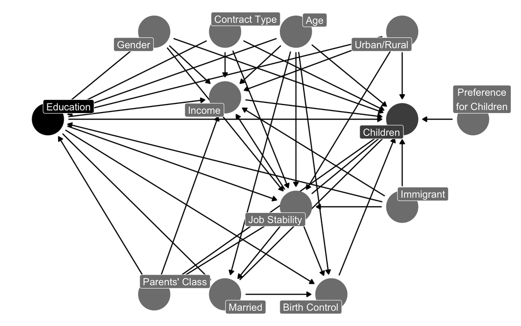

*Example: The Causal Effects of Family Background and Life Course Events on Fertility Patterns*

For the purpose of this guide, we visualize a common social science question: how does education affect fertility Morgan and Winship (2015)? The DAG model encodes a plausible, but not exhaustive, set of covariates.

## Step 3: Classify Control Variables by Role

```r
DAGassist(dag_model,
          show="roles")
```

```
## DAGassist Report:
##
## Roles:
## variable         role        Exp.  Out.  conf  med  col  dOut  dMed  dCol  dConfOn  dConfOff  NCT  NCO
## edu_year         exposure    x
## children         outcome           x
## age              confounder              x
## class            confounder              x
## contract         confounder              x
## gender           confounder              x
## immigrant        confounder              x
## urban            confounder              x
## birth_control    mediator                      x               x
## income           mediator                      x               x
## job_stability_t  mediator                      x
## married          mediator                      x               x
## pref             nco                                                                               x
## religion         nco                                                                               x
##
## Roles legend: Exp. = exposure/treatment; Out. = outcome; CON = confounder; MED = mediator; COL = collider; dOut = descendant of outcome; dMed  = descendant of mediator; dCol = descendant of collider; dConfOn = descendant of a confounder on a back-door path; dConfOff = descendant of a confounder o…
```

**Interpreting the roles table:**

- **ROLES:** `DAGassist` classifies the variables in your formula by causal role, based on the relationships in your DAG. It classifies according to these categories.
  - **X** is the `treatment` / `independent variable` / `exposure`.
  - **Y** is the `outcome` / `dependent variable`.
  - **conf** stands for `confounder`, a common cause of X and Y. Confounders create a spurious association between X and Y, and must be adjusted for.
  - **med** stands for `mediator`, a variable that lies on a path from X to Y, which transmit some of the effect from X to Y. One should not adjust for mediators if one wants to estimate the total effect of X on Y.
  - **col** stands for `collider`, a direct common descendant of X and Y. Colliders already block paths, so adjusting for it opens a spurious association between X and Y.
  - **dOut** stands for `descendant of the outcome`, a descendant of Y, which introduces bias if adjusted for.
  - **dMed** stands for `descendant of a mediator`, which should not be adjusted for when estimating total effect.
  - **dCol** stands for `descendant of a collider`. Adjusting for a descendant of a collider opens a spurious association between X and Y.
  - **dConfOn** stands for `descendant of a confounder on a back door path`, a descendant of Z that affects Y.
  - **dConfOff** stands for `descendant of a confounder off a backdoor path`, a decendant of Z that does not affect Y.
  - **other** is a catch-all category that for variables that do not fit any of the previous definitions.

## 4. Estimate Models Using DAG-Consistent Adjustment Sets

```r
DAGassist(dag_model,
          formula = lm(children ~ edu_year + age + class + gender +
                         immigrant + urban + birth_control + income +
                         married + job_stability_t + contract + pref, data = dat))
```

```
## DAGassist Report:
##
## Roles:
## variable         role        Exp.  Out.  conf  med  col  dOut  dMed  dCol  dConfOn  dConfOff  NCT  NCO
## edu_year         exposure    x
## children         outcome           x
## age              confounder              x
## class            confounder              x
## contract         confounder              x
## gender           confounder              x
## immigrant        confounder              x
## urban            confounder              x
## birth_control    mediator                      x               x
## income           mediator                      x               x
## job_stability_t  mediator                      x
## married          mediator                      x               x
## pref             nco                                                                               x
##
##  (!) Bad controls in your formula: {birth_control, income, married, job_stability_t}
## Minimal controls 1: {age, class, contract, gender, immigrant, urban}
## Canonical controls: {age, class, contract, gender, immigrant, pref, urban}
##
## Formulas:
##   original:  children ~ edu_year + age + class + gender + immigrant + urban +     birth_control + income + married + job_stability_t + contract +     pref
##
## Balance diagnostics:
##   legend: (S)MD compares covariate means between the Original complete-case sample
##           and each spec's sample; |(S)MD| > 0.10 flags a covariate whose sample
##           composition shifts (binary vars use a raw difference in means).
##   Original vs Minimal 1: n = 5000 vs 5000  balanced
##   Original vs Canonical: n = 5000 vs 5000  balanced
##   Minimal 1 vs Canonical: n = 5000 vs 5000  balanced
##
## Model comparison:
##
## +-------------------+-----------+-----------+-----------+
## |                   | Original  | Minimal 1 | Canonical |
## +===================+===========+===========+===========+
## | edu_year          | -0.122*** | -0.080*** | -0.080*** |
## +-------------------+-----------+-----------+-----------+
```

[output cut: 39 more lines]

```
## +-------------------+-----------+-----------+-----------+
## |                   | (0.114)   | (0.113)   | (0.111)   |
## +-------------------+-----------+-----------+-----------+
## | pref              | 0.581***  |           | 0.578***  |
## +-------------------+-----------+-----------+-----------+
## |                   | (0.042)   |           | (0.042)   |
## +-------------------+-----------+-----------+-----------+
## | Num.Obs.          | 5000      | 5000      | 5000      |
## +-------------------+-----------+-----------+-----------+
## | R2                | 0.227     | 0.183     | 0.213     |
## +===================+===========+===========+===========+
## | + p < 0.1, * p < 0.05, ** p < 0.01, *** p < 0.001     |
## +===================+===========+===========+===========+
##
## Roles legend: Exp. = exposure; Out. = outcome; CON = confounder; MED = mediator; COL = collider; dOut = descendant of outcome; dMed  = descendant of mediator; dCol = descendant of collider; dConfOn = descendant of a confounder on a back-door path; dConfOff = descendant of a confounder off a back-…
```

**Interpreting the model comparison table:**

The table below illustrates the varible roles permitted by each set.

| Path / Node Type | Minimal | Canonical |
| --- | --- | --- |
| Fork/Common–Cause Confounder (Z) | ✓ | ✓ |
| Chain/Mediator (M) | ✗ | ✗ |
| Collider (C) | ✗ | ✗ |
| Descendant of Mediator (N) | ✗ | ✗ |
| Descendant of Collider (Q) | ✗ | ✗ |
| Descendant of Outcome (I) | ✗ | ✗ |
| M-Bias | ✗ | ✗ |
| Butterfly Bias | ✗ | ✗ |
| Neutral Control on Treatment (E → X) | ✗ | ✓ |
| Neutral Control on Outcome (F → Y) | ✗ | ✓ |
| Descendant of Confounder *off* Backdoor Path (W) | ✗ | ✗ |
| Descendant of Confounder *on* Backdoor Path (V) | Z or V | Z and V |

*Note:* ✓ = adjust; ✗ = do not adjust. There may be multiple minimal sets; the canonical set is unique.

## 5. Recover the Interpretable Estimand

```r
DAGassist(dag_model,
          formula = lm(children ~ edu_year + age + class + gender +
                         immigrant + urban + birth_control + income +
                         married + job_stability_t + contract + pref, data = dat),
          estimand = "total")
```

```
## DAGassist Report:
##
## Roles:
## variable         role        Exp.  Out.  conf  med  col  dOut  dMed  dCol  dConfOn  dConfOff  NCT  NCO
## edu_year         exposure    x
## children         outcome           x
## age              confounder              x
## class            confounder              x
## contract         confounder              x
## gender           confounder              x
## immigrant        confounder              x
## urban            confounder              x
## birth_control    mediator                      x               x
## income           mediator                      x               x
## job_stability_t  mediator                      x
## married          mediator                      x               x
## pref             nco                                                                               x
##
##  (!) Bad controls in your formula: {birth_control, income, married, job_stability_t}
## Minimal controls 1: {age, class, contract, gender, immigrant, urban}
## Canonical controls: {age, class, contract, gender, immigrant, pref, urban}
##
## Formulas:
##   original:  children ~ edu_year + age + class + gender + immigrant + urban +     birth_control + income + married + job_stability_t + contract +     pref
##
## Balance diagnostics:
##   legend: (S)MD compares covariate means between the Original complete-case sample
##           and each spec's sample; |(S)MD| > 0.10 flags a covariate whose sample
##           composition shifts (binary vars use a raw difference in means).
##   Original vs Minimal 1: n = 5000 vs 5000  balanced
##   Original vs Canonical: n = 5000 vs 5000  balanced
##   Minimal 1 vs Canonical: n = 5000 vs 5000  balanced
##
## Model comparison:
##
## +-------------------+-----------+-----------------------+-----------------------+----------------------------+----------------------------+
## |                   | Original  | Total Minimal 1 (Raw) | Total Canonical (Raw) | Total Minimal 1 (Weighted) | Total Canonical (Weighted) |
## +===================+===========+=======================+=======================+============================+============================+
## | edu_year          | -0.122*** | -0.080***             | -0.080***             | -0.077***                  | -0.077***                  |
## +-------------------+-----------+-----------------------+-----------------------+----------------------------+----------------------------+
```

[output cut: 44 more lines]

```
## |                   | (0.042)   |                       | (0.042)               |                            |                            |
## +-------------------+-----------+-----------------------+-----------------------+----------------------------+----------------------------+
## | Num.Obs.          | 5000      | 5000                  | 5000                  | 5000                       | 5000                       |
## +-------------------+-----------+-----------------------+-----------------------+----------------------------+----------------------------+
## | R2                | 0.227     | 0.183                 | 0.213                 | 0.172                      | 0.206                      |
## +===================+===========+=======================+=======================+============================+============================+
## | + p < 0.1, * p < 0.05, ** p < 0.01, *** p < 0.001                                                                                       |
## +===================+===========+=======================+=======================+============================+============================+
##
## Weight diagnostics:
##   legend: w range reports the min-max weights by group; ESS is kish effective sample size.
##   Total Minimal 1 (Weighted): w range=0.04726..4.878 | ESS (weighted)=4368.24
##   Total Canonical (Weighted): w range=0.04731..4.877 | ESS (weighted)=4368.17
##
## Roles legend: Exp. = exposure; Out. = outcome; CON = confounder; MED = mediator; COL = collider; dOut = descendant of outcome; dMed  = descendant of mediator; dCol = descendant of collider; dConfOn = descendant of a confounder on a back-door path; dConfOff = descendant of a confounder off a back-…
```

In some cases, the target estimand is the average controlled direct effect. `DAGassist` supports recovering the controlled direct effect using sequential g-estimation via integration with the `DirectEffects` R package.

Using the prior example, we can use `DAGassist` to estimate the effect of years of education on a person’s number of children, except through birth control, income, and marital status.

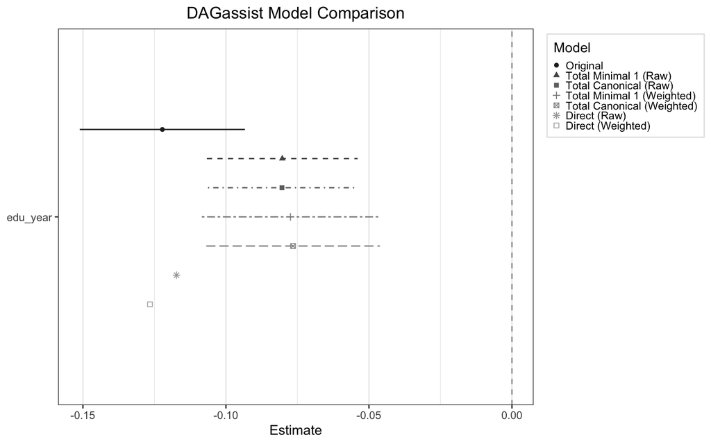

*Visualizing all estimands*

```r
library(DirectEffects)

DAGassist(dag_model,
          formula = lm(children ~ edu_year + age + class + gender +
                         immigrant + urban + birth_control + income +
                         married + job_stability_t + contract + pref, data = dat),
          estimand = c("total", "direct"),
          type = "dotwhisker")
```

## Export Publication-Grade Reports

In order to export `DAGassist` reports as files, users must first install a few commonly-used packages. Dependencies vary by export file type.

- `modelsummary` to build the **model comparison** table for **LaTeX**, **Word**, **Excel**, and **plaintext**.
  - LaTeX uses `broom` as a fallback for report generation
- `knitr` to build intermediate .md for **Word** and **plaintext** report generation.
- `rmarkdown` to convert .md files to .docx files for **Word** report generation.
- `writexl` to export **Excel** files.

Essentially, to export:

- **LaTeX** only needs `modelsummary`
- **Excel** needs `modelsummary` and `writexl`
- **plaintext** needs `modelsummary` and `knitr`
- **Word** needs `modelsummary`, `knitr`, and `rmarkdown`

Users can generate latex reports in the console (default), or to an output file via the `out =` parameter:

```r
DAGassist(dag_model,
          formula = lm(children ~ edu_year + age + class + gender +
                         immigrant + urban + birth_control + income +
                         married + job_stability_t + contract + pref, data = dat),
          type = "latex",
          out = "out/path/filename.tex")
```

**Word** and **Excel** output requires an `out =` parameter:

```r
#word example
DAGassist(dag_model,
          formula = lm(children ~ edu_year + age + class + gender +
                         immigrant + urban + birth_control + income +
                         married + job_stability_t + contract + pref, data = dat),
          type = "word", #or, type = "docx"
          out = "out/path/filename.docx")

#excel example
DAGassist(dag_model,
          formula = lm(children ~ edu_year + age + class + gender +
                         immigrant + urban + birth_control + income +
                         married + job_stability_t + contract + pref, data = dat),
          type = "excel", #or, type = "xlsx"
          out = "out/path/filename.xlsx")
```

## Testing DGP Uncertainty with PDAGs

Because DAGs encode difficult-to-verify assumptions about the data-generating process (DGP), the direction of some edges may be uncertain (Haber et al. 2022). In the example above, for instance, Urban/Rural is specified as a parent of income. In many cases, place of residence temporally precedes employment and therefore earnings. In others, however, income determines where an individual can afford to live. When the causal direction is genuinely ambiguous, selecting a single orientation may impose an unjustifiable assumption.

DAGassist addresses this problem with partially directed acyclic graphs (PDAGs). Using DAGassist::pdag_robustness(), users can designate edges whose directions are uncertain. The function enumerates all acyclic orientations of those edges and reports whether the minimal adjustment set, canonical adjustment set, or the role of any covariate changes across admissible orientations. These diagnostics indicate whether the proposed estimand is robust to directional ambiguity in the DGP.

```r
DAGassist::pdag_robustness(dag_model,
                           formula = children ~ edu_year + age + class + gender +
                             immigrant + urban + birth_control + income + married +
                             job_stability_t + contract + pref,
                           uncertain_edges = c("urban -- income",
                                               "income -- immigrant",
                                               "income -- married",
                                               "income -- edu_year"))
```

```
##
## PDAG robustness summary:
## - uncertain edges specified: 4
## - worlds evaluated (acyclic orientations): 2
## - minimal adjustment set changed: no
## - canonical adjustment set changed: no
## - covariate role classifications changed: none
## - re-estimation recommended: no
```

Users may alternatively specify uncertain edges through the main DAGassist() function:

```r
DAGassist(dag_model,
          formula = children ~ edu_year + age + class + gender + immigrant + urban +
            birth_control + income + married + job_stability_t + contract + pref, data = dat,
           uncertain_edges = c("urban -- income",
                               "income -- immigrant",
                               "income -- married",
                               "income -- edu_year"))
```

```
## DAGassist Report:
##
## Roles:
## variable         role        Exp.  Out.  conf  med  col  dOut  dMed  dCol  dConfOn  dConfOff  NCT  NCO
## edu_year         exposure    x
## children         outcome           x
## age              confounder              x
## class            confounder              x
## contract         confounder              x
## gender           confounder              x
## immigrant        confounder              x
## urban            confounder              x
## birth_control    mediator                      x               x
## income           mediator                      x               x
## job_stability_t  mediator                      x
## married          mediator                      x               x
## pref             nco                                                                               x
##
##  (!) Bad controls in your formula: {birth_control, income, married, job_stability_t}
## Minimal controls 1: {age, class, contract, gender, immigrant, urban}
## Canonical controls: {age, class, contract, gender, immigrant, pref, urban}
##
## Formulas:
##   original:  children ~ edu_year + age + class + gender + immigrant + urban +     birth_control + income + married + job_stability_t + contract +     pref
##
## Balance diagnostics:
##   legend: (S)MD compares covariate means between the Original complete-case sample
##           and each spec's sample; |(S)MD| > 0.10 flags a covariate whose sample
##           composition shifts (binary vars use a raw difference in means).
##   Original vs Minimal 1: n = 5000 vs 5000  balanced
##   Original vs Canonical: n = 5000 vs 5000  balanced
##   Minimal 1 vs Canonical: n = 5000 vs 5000  balanced
##
## Model comparison:
##
## +-------------------+-----------+-----------+-----------+
## |                   | Original  | Minimal 1 | Canonical |
## +===================+===========+===========+===========+
## | edu_year          | -0.122*** | -0.080*** | -0.080*** |
## +-------------------+-----------+-----------+-----------+
```

[output cut: 47 more lines]

```
## +-------------------+-----------+-----------+-----------+
## | R2                | 0.227     | 0.183     | 0.213     |
## +===================+===========+===========+===========+
## | + p < 0.1, * p < 0.05, ** p < 0.01, *** p < 0.001     |
## +===================+===========+===========+===========+
##
## Roles legend: Exp. = exposure; Out. = outcome; CON = confounder; MED = mediator; COL = collider; dOut = descendant of outcome; dMed  = descendant of mediator; dCol = descendant of collider; dConfOn = descendant of a confounder on a back-door path; dConfOff = descendant of a confounder off a back-…
##
## PDAG robustness summary:
## - uncertain edges specified: 4
## - worlds evaluated (acyclic orientations): 2
## - minimal adjustment set changed: no
## - canonical adjustment set changed: no
## - covariate role classifications changed: none
## - re-estimation recommended: no
```

The two implementations differ primarily in their outputs. pdag_robustness() requires only a DAG and model formula, making it useful for evaluating identification assumptions before data are available, or if one’s models are not compatable with DAGassist(). Conversely, DAGassist() requires a data frame and returns the PDAG diagnostics alongside the standard covariate-role table and re-estimated regression models.

PDAG diagnostics are calculated only over acyclic orientations. This constraint can matter substantively. In the example above, reversing income – edu_year would appear to change income from a mediator to a confounder. Yet that reversal creates a directed cycle: income → edu_year → job_stability_t → income. Because this orientation is inadmissible, it does not contribute to the robustness summary; consequently, reversing income – edu_year alone does not alter the minimal set, canonical set, or any covariate role among the remaining acyclic DAGs.

Introducing uncertainty in the job_stability_t – income edge breaks this constraint and permits additional acyclic orientations. The resulting changes in the robustness summary illustrate how PDAG diagnostics can identify assumptions about causal direction that are consequential for empirical practice.

```r
DAGassist::pdag_robustness(dag_model,
                           formula = children ~ edu_year + age + class + gender +
                             immigrant + urban + birth_control + income + married +
                             job_stability_t + contract + pref,
                           uncertain_edges = c("urban -- income",
                                               "income -- immigrant",
                                               "income -- married",
                                               "income -- edu_year",
                                               "job_stability_t -- income"))
```

```
##
## PDAG robustness summary:
## - uncertain edges specified: 5
## - worlds evaluated (acyclic orientations): 7
## - minimal adjustment set changed: yes
## - canonical adjustment set changed: yes
## - covariate role changed: mediator -> ambiguous (confounder / mediator) for income (good/bad control flip)
## - re-estimation recommended: yes
```

## Testing Missing Arrows with `add_edges()`

Whereas PDAGs address directional uncertainty in existing edges, a second set of assumptions concerns missing edges. A missing arrow in a DAG encodes a strong null (Haber et al. 2022). Because these exclusion assumptions are rarely testable, it is useful to consider whether an estimand would survive their violation.

The `add_edges` argument introduces uncertainty to specific omitted pathways. DAGassist reports whether adding an edge changes the minimal or canonical adjustment set, alters a covariate’s role, or renders the effect unidentifiable. Edges may be directed (`"A -> B"`), representing an omitted causal path, or bidirected (`"A <-> B"`), representing unmeasured confounding.

```r
DAGassist::add_edges_robustness(dag_model,
  formula = children ~ edu_year + age + class + gender + immigrant + urban +
    birth_control + income + married + job_stability_t + contract + pref,
  add_edges = c("pref -> edu_year", "religion -> edu_year", "edu_year <-> children"))
```

```
##
## Edge-addition (exclusion) robustness:
## - edges tested: 3
##   - pref -> edu_year: minimal changed: yes; canonical changed: no
##         new minimal set(s): {age, class, contract, gender, immigrant, pref, urban}
##         role changes: pref: nco->confounder
##   - religion -> edu_year: minimal changed: yes; canonical changed: no
##         new minimal set(s): {age, class, contract, gender, immigrant, religion, urban}
##         role changes: religion: nco->confounder
##   - edu_year <-> children: effect NOT identifiable if this pathway exists (no adjustment set blocks it)
## - re-estimation recommended: yes
```

```r
DAGassist(dag_model,
  formula = children ~ edu_year + age + class + gender + immigrant + urban +
    birth_control + income + married + job_stability_t + contract + pref, data = dat,
  add_edges = c("pref -> edu_year", "edu_year <-> children"))
```

```
## DAGassist Report:
##
## Roles:
## variable         role        Exp.  Out.  conf  med  col  dOut  dMed  dCol  dConfOn  dConfOff  NCT  NCO
## edu_year         exposure    x
## children         outcome           x
## age              confounder              x
## class            confounder              x
## contract         confounder              x
## gender           confounder              x
## immigrant        confounder              x
## urban            confounder              x
## birth_control    mediator                      x               x
## income           mediator                      x               x
## job_stability_t  mediator                      x
## married          mediator                      x               x
## pref             nco                                                                               x
##
##  (!) Bad controls in your formula: {birth_control, income, married, job_stability_t}
## Minimal controls 1: {age, class, contract, gender, immigrant, urban}
## Canonical controls: {age, class, contract, gender, immigrant, pref, urban}
##
## Formulas:
##   original:  children ~ edu_year + age + class + gender + immigrant + urban +     birth_control + income + married + job_stability_t + contract +     pref
##
## Balance diagnostics:
##   legend: (S)MD compares covariate means between the Original complete-case sample
##           and each spec's sample; |(S)MD| > 0.10 flags a covariate whose sample
##           composition shifts (binary vars use a raw difference in means).
##   Original vs Minimal 1: n = 5000 vs 5000  balanced
##   Original vs Canonical: n = 5000 vs 5000  balanced
##   Minimal 1 vs Canonical: n = 5000 vs 5000  balanced
##
## Model comparison:
##
## +-------------------+-----------+-----------+-----------+
## |                   | Original  | Minimal 1 | Canonical |
## +===================+===========+===========+===========+
## | edu_year          | -0.122*** | -0.080*** | -0.080*** |
## +-------------------+-----------+-----------+-----------+
```

[output cut: 39 more lines]

[output not shown]

## References

Deaton, Angus. 2010. “Instruments, Randomization, and Learning about Development.” *Journal of Economic Literature* 48: 424–55. https://doi.org/10.1257/jel.48.2.424.

Elwert, Felix. 2013. “Graphical Causal Models.” In *Handbook of Causal Analysis for Social Research*, edited by Stephen L. Morgan, vol. 54. Springer. https://doi.org/10.1007/978-1-4471-6699-3_13.

Findley, Michael G., Kyosuke Kikuta, and Michael Denly. 2021. “External Validity.” *Annual Review of Political Science* 24: 365–93.

Haber, Noah A., Mollie E. Wood, Sarah Wieten, and Alexander Breskin. 2022. “DAG with Omitted Objects Displayed (DAGWOOD): A Framework for Revealing Causal Assumptions in DAGs.” *Annals of Epidemiology* 68 (April): 64–71. https://doi.org/10.1016/j.annepidem.2022.01.001.

Hünermund, Paul, Beyers Louw, and Mikko Rönkkö. 2025. “The Choice of Control Variables in Empirical Management Research: How Causal Diagrams Can Inform the Decision.” *Leadership Quarterly* 36: 1–15.

Lundberg, Ian, Rebecca Johnson, and Brandon M. Stewart. 2021. “What Is Your Estimand? Defining the Target Quantity Connects Statistical Evidence to Theory.” *American Sociological Review* 86: 532–65. https://doi.org/10.1177/00031224211004187.

Morgan, Stephen L., and Christopher Winship. 2015. *Counterfactuals and Causal Inference: Methods and Principles for Social Research*. Cambridge University Press.

Pearl, Judea. 1995. “Causal Diagrams for Empirical Research.” *Biometrika* 82: 669–88. https://doi.org/10.1093/biomet/82.4.669.

Pearl, Judea. 2009. *Causality: Models, Reasoning, and Inference*. Cambridge University Press.

Tennant, Peter W. G., Eleanor J. Murray, Kellyn F. Arnold, et al. 2021. “Using Directed Acyclic Graphs (DAGs) to Identify Confounders in Applied Research: Review and Recommendatsion.” *International Journal of Epidemiology* 50 (2): 620–32. https://doi.org/10.1093/ije/dyaa213.